# HSE 2019 ML (bachelors 3rd course)

## Homework #4

### Student: Igor Tukh

```python
import numpy as np
import pandas as pd
import matplotlib.pyplot as plt

import os
```

```python
from tqdm import tqdm_notebook as tqdm
from collections import defaultdict
from sklearn.preprocessing import PolynomialFeatures
from sklearn.model_selection import train_test_split
from sklearn.metrics import r2_score
from sklearn import linear_model
```

```python
DATASETS_DIR = 'datasets'

def load_csv_dataset(dataset_name, label_name='label', with_header=True):
    dataset_path = os.path.join(DATASETS_DIR, dataset_name)
    if label_name is not None:
        dataset = pd.read_csv(dataset_path)
        data_columns = np.array([name for name in dataset.columns if name != label_name])
        return dataset[data_columns], dataset[np.array([label_name])]
    else:
        return pd.read_csv(dataset_path) if with_header else pd.read_csv(dataset_path, header=None)
```

### Regression

#### Datasets: noisysine.csv, hydrodynamics.csv. Both should be split into train and validate datasets (80% / 20%).

#### In every task, you need to calculate the $R^2$ score (for both datasets) and draw the resulting function on the noisysine dataset.

```python
def get_r2_score(y_pred, y_true):
    y_mean = np.mean(y_true)
    value =  1 - (1. * np.dot((y_pred - y_true), (y_pred - y_true))) / (np.dot(y_true - y_mean, y_true - y_mean))
    assert np.isclose(value, r2_score(y_true, y_pred))
    return value
```

```python
def plot_regression(X, y_true, reg, plot_title=''):
    plt.clf()
    y_pred = reg.predict(X)
    X = X.reshape(-1)
    y_pred = y_pred.reshape(-1)
    y_true = y_true.reshape(-1)
    indexes = np.argsort(X)
    X = X[indexes]
    y_true = y_true[indexes]
    y_pred = y_pred[indexes]
    plt.scatter(X, y_true)
    plt.plot(list(X), list(y_pred))
    plt.title(plot_title)
    plt.show()
```

```python
def upload_noisysine():
    data = load_csv_dataset('noisysine.csv', label_name=None)
    X = data['x'].to_numpy().reshape(-1, 1)
    y = data['y'].to_numpy()
    return X, y
```

```python
def upload_hydrodynamics():
    X, y = load_csv_dataset('hydrodynamics.csv', label_name='y')
    return X.to_numpy(), y.to_numpy().reshape(-1)
```

#### 1) (3) Implement linear and polynomial regression algorithms (for noisysine use the powers from 2 to 5, for hydrodynamics use the power of 2). No regularization.

```python
class PolynomialRegression(object):
    def __init__(self, degree=1):
        self.degree = degree
        self.p = PolynomialFeatures(degree=self.degree)

    def fit(self, X, y):
        X = self.p.fit_transform(X)
        self.w = np.linalg.inv(np.transpose(X) @ X) @ np.transpose(X) @ y

    def predict(self, X):
        X = self.p.transform(X)
        return (X @ self.w).reshape(-1)
```

```
Dataset: noisysine, power: 1, R2 score: -0.1358693966627047
```

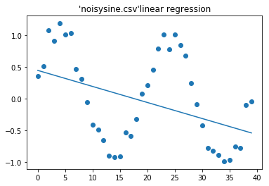

```
Dataset: noisysine, power: 2, R2 score: -0.13241207527378984
```

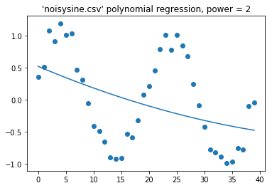

```
Dataset: noisysine, power: 3, R2 score: 0.08827822169408495
```

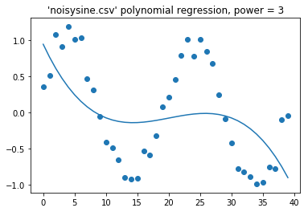

```
Dataset: noisysine, power: 4, R2 score: 0.006197296481502024
```

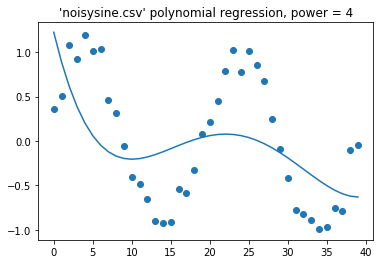

```
Dataset: noisysine, power: 5, R2 score: 0.8487045267060161
```

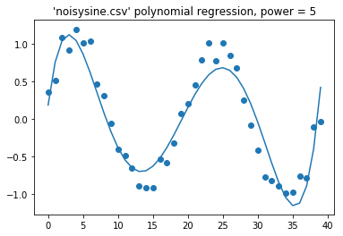

```
Dataset: hydrodynamics, power: 1, R2 score: 0.6645428621144496
Dataset: hydrodynamics, power: 2, R2 score: 0.930099114314882
```

```python
def task1():
    X, y = upload_noisysine()
    X_train, X_test, y_train, y_test = train_test_split(X, y, test_size=0.2)
    for degree in range(1, 6):
        reg = PolynomialRegression(degree)
        reg.fit(X_train, y_train)
        y_pred = reg.predict(X_test.copy())
        score = get_r2_score(y_pred, y_test)
        print('Dataset: noisysine, power: {}, R2 score: {}'.format(degree, score))
        plot_regression(X, y, reg,
                        '\'noisysine.csv\' polynomial regression, power = {}'.format(degree) if degree != 1
                        else '\'noisysine.csv\'linear regression')

    X, y = upload_hydrodynamics()
    X_train, X_test, y_train, y_test = train_test_split(X, y, test_size=0.2, random_state=23923)
    for degree in range(1, 3):
        reg = PolynomialRegression(degree)
        reg.fit(X_train, y_train)
        y_pred = reg.predict(X_test)
        score = get_r2_score(y_pred, y_test)
        print('Dataset: hydrodynamics, power: {}, R2 score: {}'.format(degree, score))

task1()
```

#### 2) (2) Implement a ridge regression algorithm and optimize the regularization parameter for every case from task #1.

```python
class RidgeRegression(object):
    def __init__(self, alpha, degree=1):
        self.degree = degree
        self.alpha = alpha
        self.p = PolynomialFeatures(degree=self.degree)

    def fit(self, X, y):
        X = self.p.fit_transform(X)
        self.w = np.linalg.inv(np.transpose(X) @ X + self.alpha * np.identity(X.shape[1])) @ np.transpose(X) @ y

    def predict(self, X):
        X = self.p.transform(X)
        return (X @ self.w).reshape(-1)
```

```python
%%javascript
IPython.OutputArea.prototype._should_scroll = function(lines) {
    return false;
}
```

```
Dataset: noisysine, power: 1, R2 score: 0.24922679361142053, alpha : 0.01
```

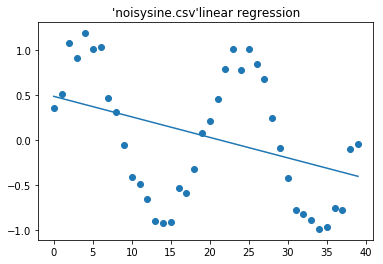

```
Dataset: noisysine, power: 1, R2 score: 0.24837010401878645, alpha : 0.1
```

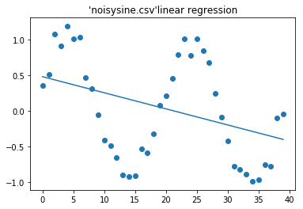

```
Dataset: noisysine, power: 1, R2 score: 0.24740920201045924, alpha : 0.2
```

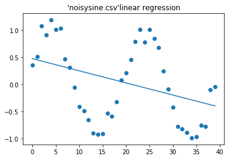

```
Dataset: noisysine, power: 1, R2 score: 0.24448426533930478, alpha : 0.5
```

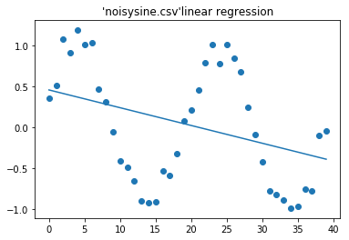

```
Dataset: noisysine, power: 1, R2 score: 0.24053206058747567, alpha : 0.9
```

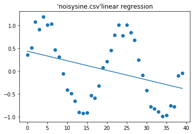

```
Dataset: noisysine, power: 1, R2 score: 0.23954141261977568, alpha : 1
```

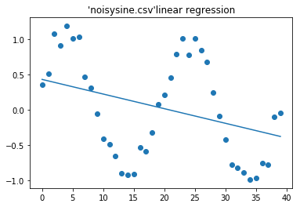

```
Dataset: noisysine, power: 2, R2 score: 0.25350440222140813, alpha : 0.01
```

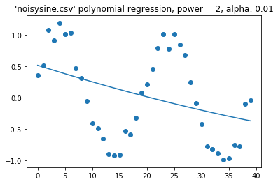

```
Dataset: noisysine, power: 2, R2 score: 0.2518490036081126, alpha : 0.1
```

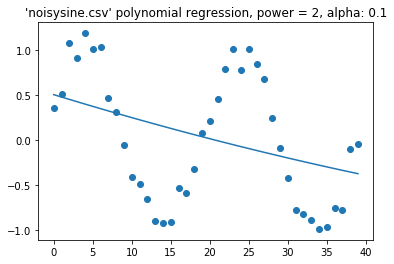

```
Dataset: noisysine, power: 2, R2 score: 0.2500494343248033, alpha : 0.2
```

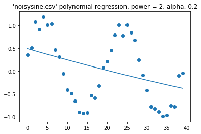

```
Dataset: noisysine, power: 2, R2 score: 0.24490234798540556, alpha : 0.5
```

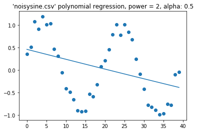

```
Dataset: noisysine, power: 2, R2 score: 0.23861053927641873, alpha : 0.9
```

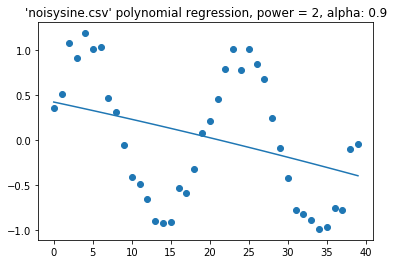

```
Dataset: noisysine, power: 2, R2 score: 0.2371346740885355, alpha : 1
```

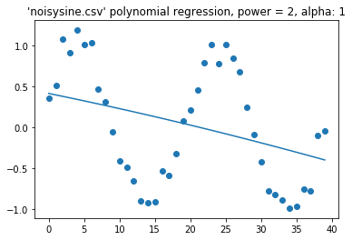

```
Dataset: noisysine, power: 3, R2 score: 0.39186179819565536, alpha : 0.01
```

[18 more figures not shown]

```
Degree 1, the best alpha: 0.01 with score 0.24922679361142053
Degree 2, the best alpha: 0.01 with score 0.25350440222140813
Degree 3, the best alpha: 0.01 with score 0.39186179819565536
Degree 4, the best alpha: 0.01 with score 0.3633870953214071
Degree 5, the best alpha: 0.01 with score 0.9669808529141489
```

```python
def task2_1():
    X, y = upload_noisysine()
    X_train, X_test, y_train, y_test = train_test_split(X, y, test_size=0.2)
    best = []
    for degree in range(1, 6):
        best_score = None
        best_alpha = None
        for alpha in [0.01, 0.1, 0.2, 0.5, 0.9, 1]:
            reg = RidgeRegression(alpha, degree)
            reg.fit(X_train, y_train)
            y_pred = reg.predict(X_test.copy())
            score = get_r2_score(y_pred, y_test)
            if best_alpha is None or best_score < score:
                best_score = score
                best_alpha = alpha
            print('Dataset: noisysine, power: {}, R2 score: {}, alpha : {}'.format(degree, score, alpha))
            plot_regression(X, y, reg,
                            '\'noisysine.csv\' polynomial regression, power = {}, alpha: {}'.format(
                                degree, alpha) if degree != 1
                            else '\'noisysine.csv\'linear regression')
        best.append((best_alpha, best_score))
    for degree in range(len(best)):
        print('Degree {}, the best alpha: {} with score {}'.format(degree + 1, best[degree][0], best[degree][1]))

task2_1()
```

```python
def task2_2():
    X, y = upload_hydrodynamics()
    X_train, X_test, y_train, y_test = train_test_split(X, y, test_size=0.2, random_state=23923)
    for degree in range(1, 3):
        for alpha in [0.01, 0.1, 0.2, 0.5, 0.9, 1]:
            reg = RidgeRegression(alpha, degree)
            reg.fit(X_train, y_train)
            y_pred = reg.predict(X_test)
            score = get_r2_score(y_pred, y_test)
            print('Dataset: hydrodynamics, power: {}, R2 score: {}, alpha: {}'.format(degree, score, alpha))

task2_2()
```

```
Dataset: hydrodynamics, power: 1, R2 score: 0.6645780774027997, alpha: 0.01
Dataset: hydrodynamics, power: 1, R2 score: 0.6636244871136763, alpha: 0.1
Dataset: hydrodynamics, power: 1, R2 score: 0.6605002908675455, alpha: 0.2
Dataset: hydrodynamics, power: 1, R2 score: 0.6429040514997841, alpha: 0.5
Dataset: hydrodynamics, power: 1, R2 score: 0.6103313050656011, alpha: 0.9
Dataset: hydrodynamics, power: 1, R2 score: 0.6015726895313483, alpha: 1
Dataset: hydrodynamics, power: 2, R2 score: 0.8933065217790265, alpha: 0.01
Dataset: hydrodynamics, power: 2, R2 score: 0.7015139745392704, alpha: 0.1
Dataset: hydrodynamics, power: 2, R2 score: 0.6644399338312179, alpha: 0.2
Dataset: hydrodynamics, power: 2, R2 score: 0.6441388257798099, alpha: 0.5
Dataset: hydrodynamics, power: 2, R2 score: 0.641250598848645, alpha: 0.9
Dataset: hydrodynamics, power: 2, R2 score: 0.641144302816588, alpha: 1
```

As we can see, in most cases $\alpha = 0.01$ has the best scores (of our alpha range)

#### 3) (3) Use the LASSO regression algorithm for every case from task #1 (i.e., from the sklearn library). Output the number of used features.

```python
class RegressorShell(object):
    def __init__(self, reg, p):
        self.reg = reg
        self.p = p

    def predict(self, X):
        X = self.p.transform(X.reshape(-1, 1))
        return self.reg.predict(X)
```

```
Dataset: noisysine, power: 1, R2 score: 0.04069721706423213, alpha : 0.001, used features: 1
```

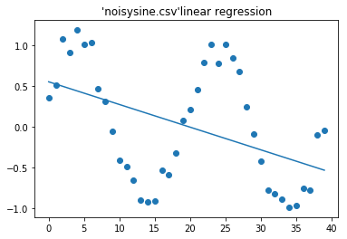

```
Dataset: noisysine, power: 1, R2 score: 0.04097520120701714, alpha : 0.01, used features: 1
```

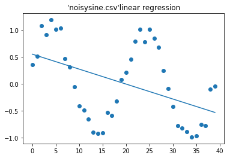

```
Dataset: noisysine, power: 1, R2 score: 0.04365156184861474, alpha : 0.1, used features: 1
```

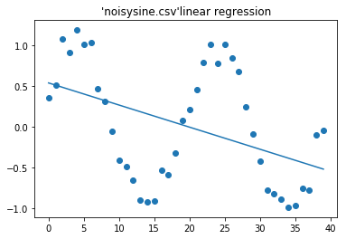

```
Dataset: noisysine, power: 1, R2 score: 0.04640462979619997, alpha : 0.2, used features: 1
```

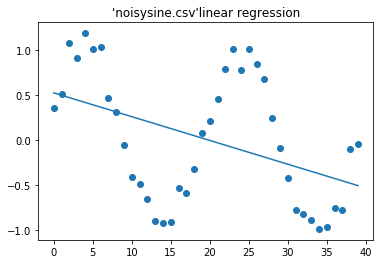

```
Dataset: noisysine, power: 1, R2 score: 0.05327015301600524, alpha : 0.5, used features: 1
```

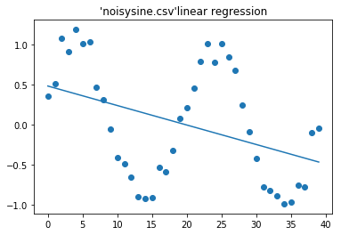

```
Dataset: noisysine, power: 1, R2 score: 0.05917226252219421, alpha : 0.9, used features: 1
```

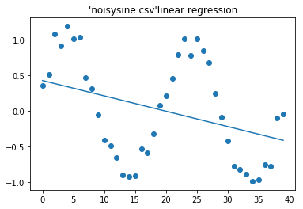

```
Dataset: noisysine, power: 1, R2 score: 0.060067089639178506, alpha : 1, used features: 1
```

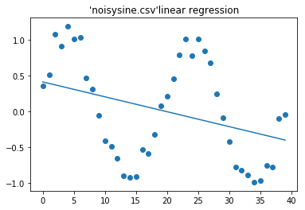

```
Dataset: noisysine, power: 2, R2 score: 0.0424027957084222, alpha : 0.001, used features: 2
```

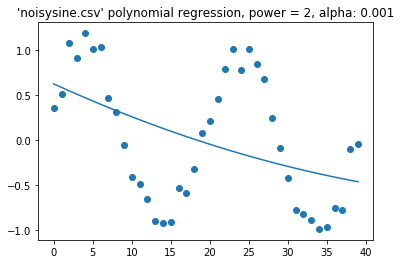

```
Dataset: noisysine, power: 2, R2 score: 0.04266475060263575, alpha : 0.01, used features: 2
```

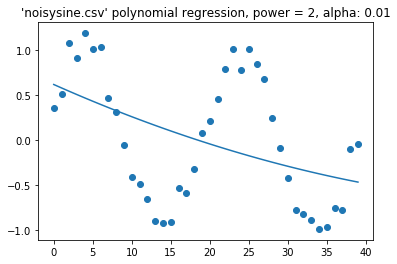

```
Dataset: noisysine, power: 2, R2 score: 0.04418145671298224, alpha : 0.1, used features: 2
```

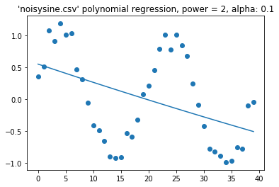

```
Dataset: noisysine, power: 2, R2 score: 0.044028723000176906, alpha : 0.2, used features: 2
```

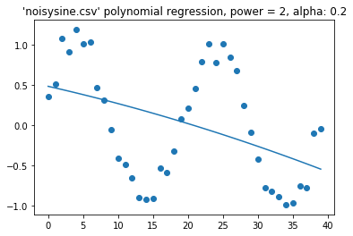

```
Dataset: noisysine, power: 2, R2 score: 0.03707280377660582, alpha : 0.5, used features: 1
```

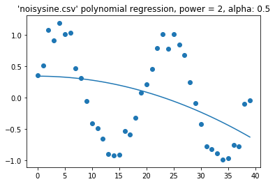

```
Dataset: noisysine, power: 2, R2 score: 0.03731022648522009, alpha : 0.9, used features: 1
```

[23 more figures not shown]

```
Degree 1, the best alpha: 1 with score 0.060067089639178506 and 1 feature(s)
Degree 2, the best alpha: 0.1 with score 0.04418145671298224 and 2 feature(s)
Degree 3, the best alpha: 0.001 with score 0.29398028276376187 and 3 feature(s)
Degree 4, the best alpha: 0.01 with score 0.269251118089184 and 4 feature(s)
Degree 5, the best alpha: 0.2 with score 0.645969905388465 and 4 feature(s)
```

```python
def task3_1():
    X, y = upload_noisysine()
    X_train, X_test, y_train, y_test = train_test_split(X, y, test_size=0.2)
    best = []
    for degree in range(1, 6):
        best_score = None
        best_alpha = None
        best_features_amount = 0
        for alpha in [0.001, 0.01, 0.1, 0.2, 0.5, 0.9, 1]:
            reg = linear_model.Lasso(alpha=alpha, max_iter=100000)
            p = PolynomialFeatures(degree=degree)
            X_train_p = p.fit_transform(X_train)
            reg.fit(X_train_p, y_train)
            y_pred = reg.predict(p.transform(X_test))
            score = get_r2_score(y_pred, y_test)
            features_amount = sum([0 if np.isclose(coef, 0) else 1 for coef in reg.coef_])
            if best_alpha is None or best_score < score:
                best_score = score
                best_alpha = alpha
                best_features_amount = features_amount
            print('Dataset: noisysine, power: {}, R2 score: {}, alpha : {}, used features: {}'.format(
                degree, score, alpha, features_amount))
            plot_regression(X.copy(), y, RegressorShell(reg, p),
                            '\'noisysine.csv\' polynomial regression, power = {}, alpha: {}'.format(
                                degree, alpha) if degree != 1
                            else '\'noisysine.csv\'linear regression')
        best.append((best_alpha, best_score, best_features_amount))
    for degree in range(len(best)):
        print('Degree {}, the best alpha: {} with score {} and {} feature(s)'.format(
            degree + 1, best[degree][0], best[degree][1], best[degree][2]))

task3_1()
```

```python
def task3_2():
    X, y = upload_hydrodynamics()
    X_train, X_test, y_train, y_test = train_test_split(X, y, test_size=0.2)
    best = []
    for degree in range(1, 3):
        best_score = None
        best_alpha = None
        best_features_amount = 0
        for alpha in [0.001, 0.01, 0.1, 0.2, 0.5, 0.9, 1]:
            reg = linear_model.Lasso(alpha=alpha, max_iter=100000)
            p = PolynomialFeatures(degree=degree)
            X_train_p = p.fit_transform(X_train)
            reg.fit(X_train_p, y_train)
            y_pred = reg.predict(p.transform(X_test))
            score = get_r2_score(y_pred, y_test)
            features_amount = sum([0 if np.isclose(coef, 0) else 1 for coef in reg.coef_])
            if best_alpha is None or best_score < score:
                best_score = score
                best_alpha = alpha
                best_features_amount = features_amount
            print('Dataset: noisysine, power: {}, R2 score: {}, alpha : {}, used features: {}'.format(
                degree, score, alpha, features_amount))
        best.append((best_alpha, best_score, best_features_amount))
    for degree in range(len(best)):
        print('Degree {}, the best alpha: {} with score {} and {} feature(s)'.format(
            degree + 1, best[degree][0], best[degree][1], best[degree][2]))

task3_2()
```

```
Dataset: noisysine, power: 1, R2 score: 0.6717896272944843, alpha : 0.001, used features: 5
Dataset: noisysine, power: 1, R2 score: 0.6709404436942485, alpha : 0.01, used features: 3
Dataset: noisysine, power: 1, R2 score: 0.6631539978798042, alpha : 0.1, used features: 2
Dataset: noisysine, power: 1, R2 score: 0.6470031053126297, alpha : 0.2, used features: 2
Dataset: noisysine, power: 1, R2 score: 0.549875130006593, alpha : 0.5, used features: 2
Dataset: noisysine, power: 1, R2 score: 0.3065112543720724, alpha : 0.9, used features: 1
Dataset: noisysine, power: 1, R2 score: 0.22542238636751766, alpha : 1, used features: 1
Dataset: noisysine, power: 2, R2 score: 0.9265943319770658, alpha : 0.001, used features: 16
Dataset: noisysine, power: 2, R2 score: 0.9059234730123935, alpha : 0.01, used features: 10
Dataset: noisysine, power: 2, R2 score: 0.6676622240010819, alpha : 0.1, used features: 6
Dataset: noisysine, power: 2, R2 score: 0.6661285023477166, alpha : 0.2, used features: 4
Dataset: noisysine, power: 2, R2 score: 0.6584927475853557, alpha : 0.5, used features: 4
Dataset: noisysine, power: 2, R2 score: 0.6427088266223242, alpha : 0.9, used features: 3
Dataset: noisysine, power: 2, R2 score: 0.6377661679430391, alpha : 1, used features: 3
Degree 1, the best alpha: 0.001 with score 0.6717896272944843 and 5 feature(s)
Degree 2, the best alpha: 0.001 with score 0.9265943319770658 and 16 feature(s)
```

As we can see, we have mostly worse results